# meth03_regional_analysis.R

[figure not shown]

[figure not shown]

[figure not shown]

Load package for regional analysis “DMRcate” see [Peters et al. Bioinformatics 2015](https://epigeneticsandchromatin.biomedcentral.com/articles/10.1186/1756-8935-8-6).  
Other popular options for conducting Regional DNA methylation analysis in R are Aclust and bumphunter

```r
suppressMessages(library(DMRcate)) # Popular package for regional DNA methylation analysis
```

First we need to define a model

```r
model = model.matrix( ~SMOKE_STATUS+SEX+AGE+CD8T+NK+Bcell+Mono+Gran,data=pheno)
```

Regions are now agglomerated from groups of significant probes Let’s run the regional analysis using the Beta-values from our preprocessed data

```r
myannotation <- cpg.annotate("array", betas.clean, analysis.type="differential",arraytype="EPIC",
                             what="Beta",design=model, coef=2)
```

```
## Your contrast returned no individually significant probes. Try increasing the fdr. Alternatively, set pcutoff manually in dmrcate() to return DMRs, but be warned there is an increased risk of Type I errors.
```

Introduction to limma see [Smyth GK. Stat Appl Genet Mol Biol 2004](https://www.ncbi.nlm.nih.gov/pubmed/16646809).

```r
suppressMessages(library(limma,minfi))
EWAS.limma <- eBayes(lmFit(betas.clean, design=model))
topTable(EWAS.limma, coef=2, number=Inf, sort.by="p")[1:10,]
```

```
##                  logFC   AveExpr         t      P.Value adj.P.Val        B
## cg07843905  0.03292233 0.1189206  8.563712 1.736238e-06 0.9188306 4.691747
## cg07162861 -0.08715999 0.6434627 -8.119657 3.027766e-06 0.9188306 4.100682
## cg24709019 -0.01809885 0.9504813 -7.944631 3.792515e-06 0.9188306 3.861444
## cg23958524  0.04079796 0.8117967  7.252486 9.571800e-06 0.9188306 2.878938
## cg21931972 -0.01500877 0.9389193 -7.158304 1.090598e-05 0.9188306 2.740604
## cg24749455 -0.01043742 0.9557050 -6.961444 1.437788e-05 0.9188306 2.447752
## cg02694972 -0.01483972 0.9576849 -6.852733 1.678433e-05 0.9188306 2.283864
## cg05797501  0.01622577 0.9446414  6.800813 1.808168e-05 0.9188306 2.205041
## cg04456029 -0.03574526 0.8811857 -6.616247 2.362805e-05 0.9188306 1.921943
## cg17907003 -0.05579646 0.7049408 -6.603338 2.407839e-05 0.9188306 1.901973
```

We don’t find any significant regions (FDR<0.05), So let’s try a simpler model as an example

```r
model = model.matrix( ~SMOKE_STATUS+SEX+AGE,data=pheno )

EWAS.limma <- eBayes(lmFit(betas.clean, design=model))
topTable(EWAS.limma, coef=2, number=Inf, sort.by="p")[1:10,]
```

```
##                  logFC   AveExpr          t      P.Value   adj.P.Val
## cg05575921 -0.21651404 0.7870612 -10.871123 4.277878e-09 0.003402795
## cg17417856 -0.04763627 0.6535269  -9.249994 4.609053e-08 0.018331124
## cg05249683 -0.03462350 0.7180354  -8.982465 7.015845e-08 0.018602279
## cg14585907  0.01323220 0.9153905   8.766809 9.904849e-08 0.019696783
## cg04729913 -0.06602445 0.3083772  -8.380007 1.864802e-07 0.025844806
## cg25648203 -0.05438941 0.8756780  -8.353280 1.949472e-07 0.025844806
## cg26703534 -0.06598301 0.7743715  -8.202610 2.508208e-07 0.028501846
## cg05694926 -0.03680511 0.7573550  -7.657700 6.393802e-07 0.057610136
## cg10512781 -0.08085936 0.7133273  -7.622980 6.795550e-07 0.057610136
## cg10765427 -0.04749953 0.5686158  -7.555967 7.647193e-07 0.057610136
##                    B
## cg05575921 10.197995
## cg17417856  7.710850
## cg05249683  7.271843
## cg14585907  6.911677
## cg04729913  6.251294
## cg25648203  6.204971
## cg26703534  5.942129
## cg05694926  4.967105
## cg10512781  4.903667
## cg10765427  4.780774
```

```r
myannotation <- cpg.annotate("array", betas.clean, analysis.type="differential",arraytype="EPIC",
                             what="Beta",design=model, coef=2)
```

```
## Your contrast returned 8 individually significant probes; a small but real effect. Consider manually setting the value of pcutoff to return more DMRs, but be warned that doing this increases the risk of Type I errors.
```

Regions are now agglomerated from groups of significant probes where the distance to the next consecutive probe is less than lambda nucleotides away

```r
dmrcoutput.smoking <- dmrcate(myannotation, lambda=1000, C=2)
```

[output not shown]

[output not shown]

[output not shown]

[output not shown]

[output not shown]

[output not shown]

[output not shown]

[output not shown]

[output not shown]

[output not shown]

[output not shown]

[output not shown]

[output not shown]

[output not shown]

[output not shown]

[output not shown]

[output not shown]

[output not shown]

[output not shown]

[output not shown]

[output not shown]

[output not shown]

```
## Demarcating regions...
```

```
## Done!
```

Let’s look at the results

```r
head(dmrcoutput.smoking$results)
```

```
##                      coord no.cpgs       minfdr  Stouffer  maxbetafc
## 1 chr1:147781827-147782279       4 7.706145e-32 0.0220566 -0.1365983
## 2 chr1:153600064-153600156       3 2.376482e-29 0.2031225 -0.1055657
##    meanbetafc
## 1 -0.09766585
## 2 -0.08814687
```

Visualizing the data can help us understand where the region lies relative to promoters, CpGs islands or enhancers Let’s extract the genomic ranges and annotate to the genome

```r
results.ranges <- extractRanges(dmrcoutput.smoking, genome = "hg19")
```

Plot the DMR using the Gviz if you are interested in plotting genomic data the Gviz is extremely useful Let’s look at the first region

```r
results.ranges[1]
```

```
## GRanges object with 1 range and 6 metadata columns:
##                            seqnames              ranges strand |   no.cpgs
##                               <Rle>           <IRanges>  <Rle> | <integer>
##   chr1:147781827-147782279     chr1 147781827-147782279      * |         4
##                                          minfdr           Stouffer
##                                       <numeric>          <numeric>
##   chr1:147781827-147782279 7.70614480558288e-32 0.0220566012913112
##                                     maxbetafc          meanbetafc
##                                     <numeric>           <numeric>
##   chr1:147781827-147782279 -0.136598283264533 -0.0976658501051973
##                            overlapping.promoters
##                                      <character>
##   chr1:147781827-147782279                  <NA>
##   -------
##   seqinfo: 1 sequence from an unspecified genome; no seqlengths
```

```r
# set up the grouping variables and colours
cols = c("magenta","red")[pheno$SMOKE_STATUS]
names(cols) = levels(pheno$SMOKE_STATUS)[pheno$SMOKE_STATUS]
```

Draw the plot for the top DMR

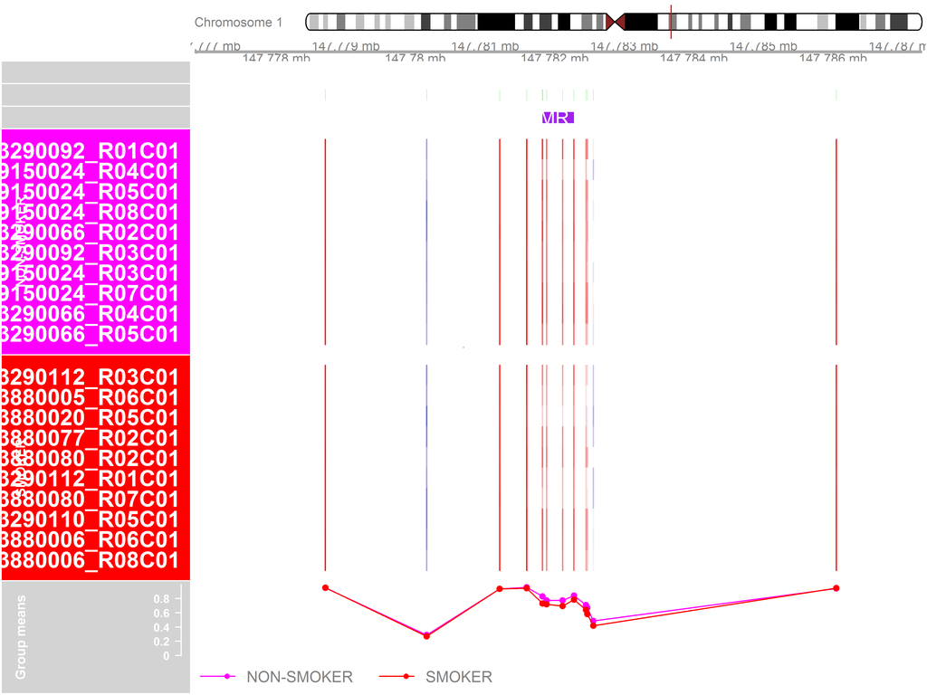

```r
DMR.plot(ranges=results.ranges, dmr=1, CpGs=betas.clean, phen.col=cols, what = "Beta",
         arraytype = "EPIC", pch=16, toscale=TRUE, plotmedians=TRUE,
         genome="hg19", samps=1:nrow(pheno))
```

cleanup

```r
rm(tx.hg19,tx.hg38,tx.mm10,snpsall,myBetas,myannotation,crosshyb,XY.probes);gc()
```

```
##             used   (Mb) gc trigger   (Mb)  max used   (Mb)
## Ncells  16033822  856.3   31947922 1706.3  31947922 1706.3
## Vcells 167840493 1280.6  459167233 3503.2 481217305 3671.4
```

Extracting CpGs-names and locations

```r
coord = dmrcoutput.smoking$results$coord[1]
coord = stri_match(coord,regex="^(chr.+):(\\d+)-(\\d+)$")

chr = coord[2]
start = as.integer(coord[3])
end = as.integer(coord[4])
```

CpG ID and individual metrics

```r
cpgs = subset(dmrcoutput.smoking$input, CHR == chr & pos >= start & pos <= end)
knitr::kable(cpgs)
```

|  | ID | weights | CHR | pos | betafc | indfdr | is.sig | raw | fdr | sig | step.dmr |
| --- | --- | --- | --- | --- | --- | --- | --- | --- | --- | --- | --- |
| 45778 | cg18140268 | 5.801619 | chr1 | 147781827 | -0.1365983 | 0.1044358 | FALSE | 0 | 0 | TRUE | TRUE |
| 45779 | cg19265480 | 4.659366 | chr1 | 147781887 | -0.0720433 | 0.1845399 | FALSE | 0 | 0 | TRUE | FALSE |
| 45780 | cg23206461 | 4.591373 | chr1 | 147782116 | -0.1046553 | 0.1877897 | FALSE | 0 | 0 | TRUE | FALSE |
| 45781 | cg13392957 | 4.887752 | chr1 | 147782279 | -0.0773665 | 0.1622916 | FALSE | 0 | 0 | TRUE | FALSE |

Load package for Age-Prediction

```r
library(wateRmelon)
DNAmAge<-as.vector(agep(betas.clean))
```

Agreement between chronological age and DNAm-Age Correlation

```r
cor.test(DNAmAge,pheno$AGE)
```

```
##
##  Pearson's product-moment correlation
##
## data:  DNAmAge and pheno$AGE
## t = 3.3431, df = 18, p-value = 0.003619
## alternative hypothesis: true correlation is not equal to 0
## 95 percent confidence interval:
##  0.2429425 0.8332335
## sample estimates:
##       cor
## 0.6189245
```

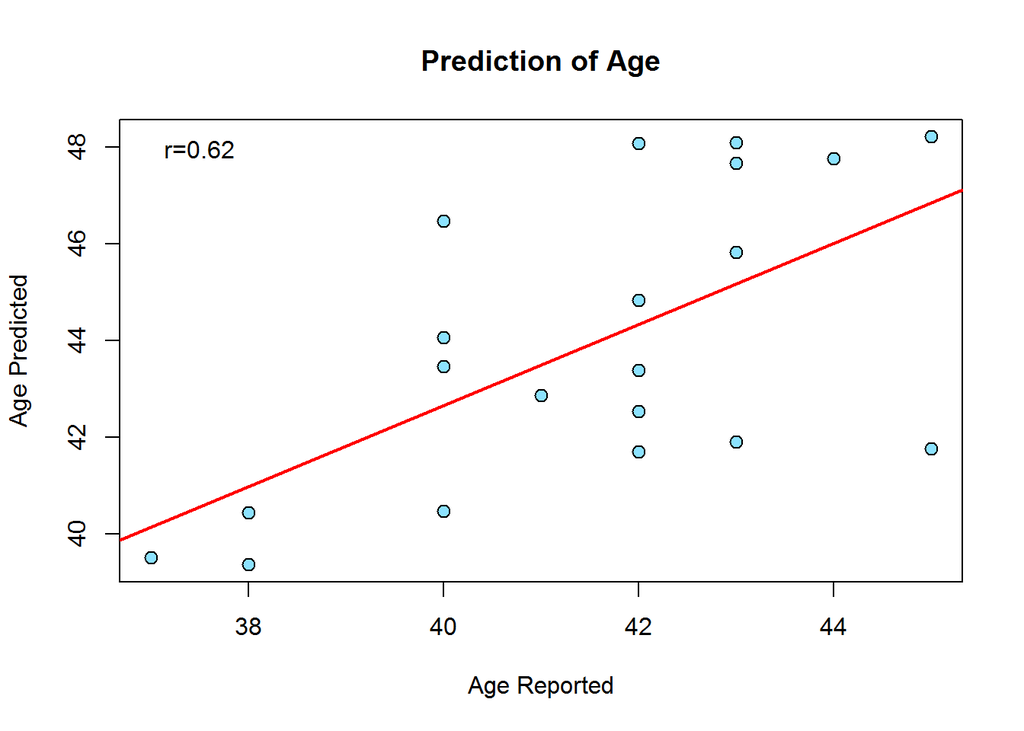

```r
plot(pheno$AGE,DNAmAge,pch=21,ylab="Age Predicted",
     xlab="Age Reported",cex=1.2, bg=alpha("deepskyblue",0.45),main="Prediction of Age")
legend("topleft",legend=paste0("r=",round(cor(DNAmAge,pheno$AGE),2)),bty="n")
abline(lm(DNAmAge~pheno$AGE),col="red",lw=2)
```

Age Acceleration Residuals

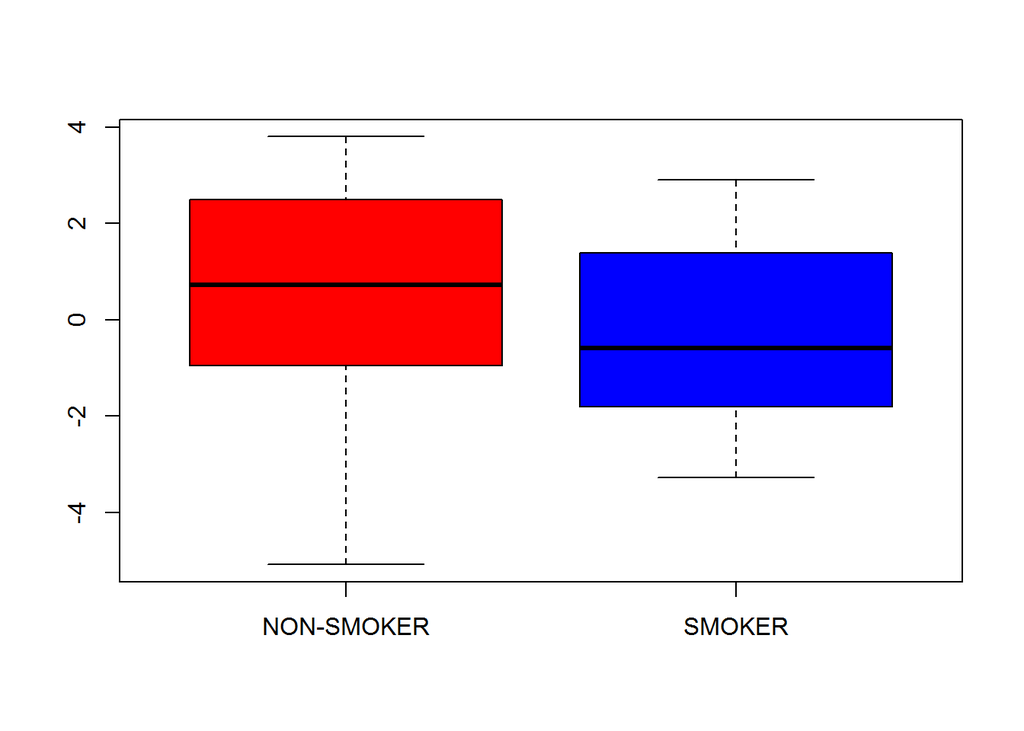

```r
AgeAccelerationResidual<-residuals(lm(DNAmAge~pheno$AGE))
boxplot(AgeAccelerationResidual ~pheno$SMOKE_STATUS, col=c("red","blue"))
```

```r
wilcox.test(AgeAccelerationResidual ~ pheno$SMOKE_STATUS)
```

```
##
##  Wilcoxon rank sum test
##
## data:  AgeAccelerationResidual by pheno$SMOKE_STATUS
## W = 60, p-value = 0.4813
## alternative hypothesis: true location shift is not equal to 0
```

```r
t.test(AgeAccelerationResidual ~ pheno$SMOKE_STATUS)
```

```
##
##  Welch Two Sample t-test
##
## data:  AgeAccelerationResidual by pheno$SMOKE_STATUS
## t = 0.65345, df = 16.126, p-value = 0.5227
## alternative hypothesis: true difference in means is not equal to 0
## 95 percent confidence interval:
##  -1.581339  2.991928
## sample estimates:
## mean in group NON-SMOKER     mean in group SMOKER
##                0.3526473               -0.3526473
```

Online Calculator

```r
Horvath<-read.csv("C:/EBC3/Data/MethylationData.output.csv")
cor.test(Horvath$DNAmAge,pheno$AGE)
```

```
##
##  Pearson's product-moment correlation
##
## data:  Horvath$DNAmAge and pheno$AGE
## t = 2.8604, df = 18, p-value = 0.0104
## alternative hypothesis: true correlation is not equal to 0
## 95 percent confidence interval:
##  0.1547980 0.8029193
## sample estimates:
##       cor
## 0.5590248
```

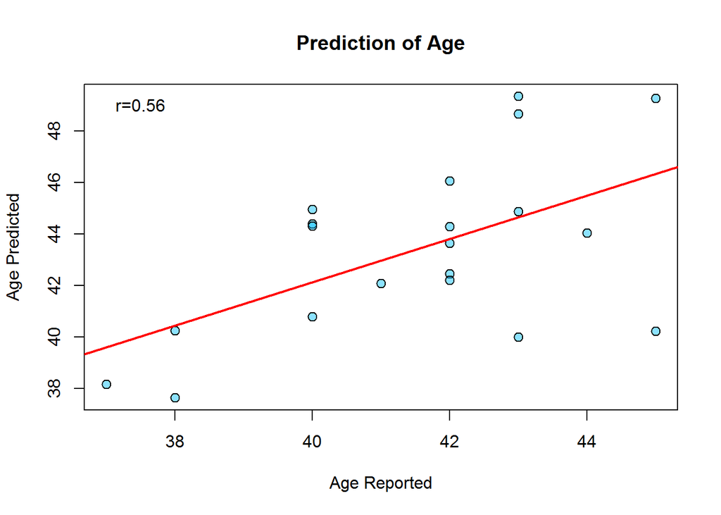

```r
plot(pheno$AGE,Horvath$DNAmAge,pch=21,ylab="Age Predicted",
     xlab="Age Reported",cex=1.2, bg=alpha("deepskyblue",0.45),main="Prediction of Age")
legend("topleft",legend=paste0("r=",round(cor(Horvath$DNAmAge,pheno$AGE),2)),bty="n")
abline(lm(Horvath$DNAmAge~pheno$AGE),col="red",lw=2)
```

End of script 03